# Proyecto Xiphophorus

### 3.5.8 *X. variatus*

```r
similaridadvariatusvsbirchmani<-ecospat.niche.equivalency.test(z1=z8 , z2=z1, rep=100, ncores = cores)
similaridadvariatusvscortezi<-ecospat.niche.equivalency.test(z1=z8 , z2=z2, rep=100, ncores = cores)
similaridadvariatusvsmalinche<-ecospat.niche.equivalency.test(z1=z8 , z2=z3, rep=100, ncores = cores)
similaridadvariatusvsmultilineatus<-ecospat.niche.equivalency.test(z1=z8 , z2=z4, rep=100, ncores = cores)
similaridadvariatusvsneza<-ecospat.niche.equivalency.test(z1=z8 , z2=z5, rep=100, ncores = cores)
similaridadvariatusvsnigrensis<-ecospat.niche.equivalency.test(z1=z8 , z2=z6, rep=100, ncores = cores)
similaridadvariatusvspygmaeus<-ecospat.niche.equivalency.test(z1=z8 , z2=z7, rep=100, ncores = cores)
```

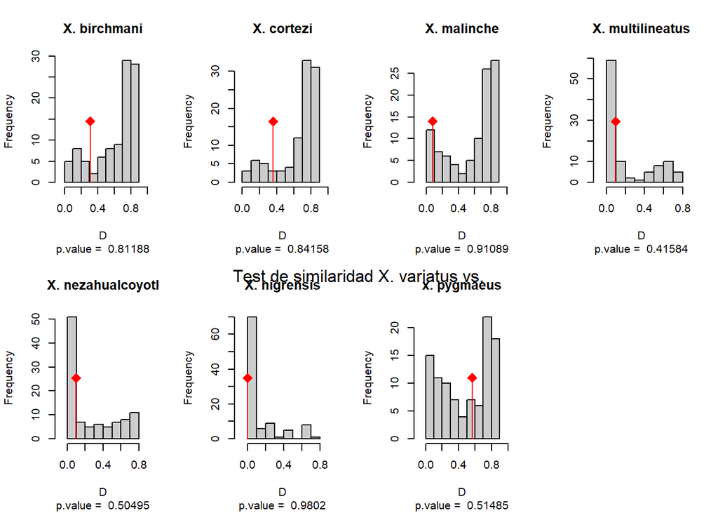

```r
par(mfrow=c(2,4))
ecospat.plot.overlap.test(similaridadvariatusvsbirchmani,"D","X. birchmani")
ecospat.plot.overlap.test(similaridadvariatusvscortezi,"D","X. cortezi")
ecospat.plot.overlap.test(similaridadvariatusvsmalinche,"D","X. malinche")
ecospat.plot.overlap.test(similaridadvariatusvsmultilineatus,"D","X. multilineatus")
ecospat.plot.overlap.test(similaridadvariatusvsneza,"D","X. nezahualcoyotl")
ecospat.plot.overlap.test(similaridadvariatusvsnigrensis,"D","X. nigrensis")
ecospat.plot.overlap.test(similaridadvariatusvspygmaeus,"D","x. pygmaeus")
mtext("Test de similaridad X. variatus vs.", side = 3,  line = -21, outer = TRUE)
```

### 3.5.9 Conclusiones respecto a las pruebas de similaridad.

En estos casos el valor de D en general es bastante bajo, indicando que no existe suficiente conservadurismo entre los nichos de las especies. Los valores de D en estas pruebas, pero la P de D si, debido a que cada uno de las pruebas intentan probar cosas diferentes. Equivalencia nos dice si nuestros sobrelapes son más diferentes que el azar, y la similitud nos indica si el sobrelape es más similar que lo esperado por azar. En este caso la P sigue siendo bastante mala, lo cual puede ser producto de las pocas ocurrencias que hay para cada una de las especies al momento de obtener los valores usados para el calculo del modelo de nicho. Quizá usando un modelo más robusto, o con más ocurrencias, o inclusive usando mayor número de repeticiones sería mejorar P para comprobar que los resultados son estadísticamente significativos. Sin embargo, logramos comprobar que existen diferencias importantes en los nichos predichos para cada una de las especies. Aúnque las especies coexistan en un mismo lugar, el hecho de que cada una tenga valores diferentes para las condiciones bioclimáticas que necesita, nos muestra que existen factores que consiguen separar a estas especies unas de otras.

# 4 Análisis filogenéticos

## 4.1 Obtención de secuencias FASTA las secuencias son usadas en análisis filogenéticos

Es recomendable utilizar dos o más genes para esta clase de pruebas.En este caso utilizaremos ND2 (subunidad 2 de la deshidrogenasa NADH) y CYTB (citocromo B) por ser genes con buen grado de conservación. Necesitamos que los genes no sufran demasiadas mutaciones o sean propensos al cambio, para que los resultados sean más confiables.

### 4.1.1 Para el gen ND2

```r
Xiphophorusnd2_accession_numbers <- c("KJ697263", "KJ697261", "KJ697260", "KJ697259", "KJ697249", "KJ697250", "KJ697258", "KJ697251", "AF031390") #Crea un vector con los números de acceso requeridos
Xiphophorusnd2_sequences <- read.GenBank(Xiphophorusnd2_accession_numbers)  #Lee las secuencias y las guarda como un objeto bin
Xiphophorusnd2_sequences    #Un resumen de lo que es el objeto, incluyendo su composición en bases
```

```
## 9 DNA sequences in binary format stored in a list.
##
## Mean sequence length: 1296.667
##    Shortest sequence: 1105
##     Longest sequence: 1321
##
## Labels:
## KJ697263
## KJ697261
## KJ697260
## KJ697259
## KJ697249
## KJ697250
## ...
##
## Base composition:
##     a     c     g     t
## 0.270 0.349 0.124 0.257
## (Total: 11.67 kb)
```

```r
Xiphophorusnd2_sequences_GenBank_IDs <- paste(attr(Xiphophorusnd2_sequences, "species"), names(Xiphophorusnd2_sequences), sep ="_ND2_") #constuye un vector con la especie, el número de acceso de la secuencia en Genbank
write.dna(Xiphophorusnd2_sequences, file ="SECUENCIASND2.fasta", format = "fasta", append = FALSE, nbcol = 6, colsep = " ", colw = 10) #Escribe el archivo en formato FASTA

Xiphophorusnd2_seq_seqinr_format <- read.fasta(file = "SECUENCIASND2.fasta", seqtype = "DNA", as.string = TRUE, forceDNAtolower = FALSE) #Lee el archivo FASTA usando el paquete seqinr
write.fasta(sequences = Xiphophorusnd2_seq_seqinr_format, names = Xiphophorusnd2_sequences_GenBank_IDs, nbchar = 10, file.out = "SecuenciasfinalND2.fasta")  #Reescribe el archivo FASTA usando un nombre de vector que se creo antes
```

### 4.1.1 Para el gen CYTB

```r
XiphophorusCYTB_accession_numbers <- c("KJ696865", "KJ696863", "KJ696862", "KJ696861", "KJ696850", "KJ696852", "KJ696860", "KJ696853", "KJ696840") #Crea un vector con los números de acceso requeridos
XiphophorusCYTB_sequences <- read.GenBank(XiphophorusCYTB_accession_numbers)  #Lee las secuencias y las guarda como un objeto bin
XiphophorusCYTB_sequences_GenBank_IDs <- paste(attr(XiphophorusCYTB_sequences, "species"), names(XiphophorusCYTB_sequences), sep ="_CYTB_") #constuye un vector con la especie, el número de acceso de la secuencia en Genbank
write.dna(XiphophorusCYTB_sequences, file ="SECUENCIASCYTB.fasta", format = "fasta", append = FALSE, nbcol = 6, colsep = " ", colw = 10) #Escribe el archivo en formato FASTA

XiphophorusCYTB_seq_seqinr_format <- read.fasta(file = "SECUENCIASCYTB.fasta", seqtype = "DNA", as.string = TRUE, forceDNAtolower = FALSE) #Lee el archivo FASTA usando el paquete seqinr
write.fasta(sequences = XiphophorusCYTB_seq_seqinr_format, names = XiphophorusCYTB_sequences_GenBank_IDs, nbchar = 10, file.out = "SecuenciasfinalCYTB.fasta")  #Reescribe el archivo FASTA usando un nombre de vector que se creo antes
```

## 4.2 Alineamiento de sequencias

Es necesario alinear las secuencias, ya que los genes no siempre estan en el acomodo apropiado, debido a cambios que pueden haber sufrido durante su evolución. Por lo que hay que alinear ambas secuencias para poder ser comparadas apropiadamente.

```r
Xiphophorusnd2_seq<-readDNAStringSet("SecuenciasfinalND2.fasta")
Xiphophorusnd2_align<-msa(Xiphophorusnd2_seq)
```

```
## use default substitution matrix
```

```r
Xiphophorusnd2_align
```

```
## CLUSTAL 2.1
##
## Call:
##    msa(Xiphophorusnd2_seq)
##
## MsaDNAMultipleAlignment with 9 rows and 1321 columns
##     aln                                                    names
## [1] TCTTAGTGCTCCCACTACACCACTTC...GGAAGGCCTCGATCCTACAAATTCT Xiphophorus_conti...
## [2] TCTTAGTGCTCCCACTACACCACTTC...GGAAGGCCTCGATCCTACAAATTCT Xiphophorus_multi...
## [3] TCTTAGTGCTCCCACTACACCACTTC...GGAAGGCCTCGATCCTACAAATTCT Xiphophorus_birch...
## [4] TCTTAGTGCTCCCACTACACCACTTC...GGAAGGCCTCGATCCTACAAATTCT Xiphophorus_nigre...
## [5] TCTTAGTGCTCCCACTACACCACTTC...GGAAGGCCTCGATCCTACAAATTCT Xiphophorus_corte...
## [6] TCTTAGTGCTCCCACTACACCACTTC...GGAAGGCCTCGATCCTACAAACTCT Xiphophorus_nezah...
## [7] TCTTAGTGCTCCCACTACACCACTTC...GGAAGGCCTCGATCCTACAAATTCT Xiphophorus_pygma...
## [8] TCTTAGTGCTCCCACTACACCACTTC...GGAAGGCCTCGATCCTACAAATTCT Xiphophorus_varia...
## [9] --------------------------...------------------------- Poecilia_sphenops...
## Con TCTTAGTGCTCCCACTACACCACTTC...GGAAGGCCTCGATCCTACAAATTCT Consensus
```

```r
Xiphophorusnd2_DNAbin<-msaConvert(Xiphophorusnd2_align, type = "ape::DNAbin")
Xiphophorusnd2_DNA<-as_dna(Xiphophorusnd2_DNAbin)

XiphophorusCYTB_seq<-readDNAStringSet("SecuenciasfinalCYTB.fasta")
XiphophorusCYTB_align<-msa(XiphophorusCYTB_seq)
```

```
## use default substitution matrix
```

```r
XiphophorusCYTB_DNAbin<-msaConvert(XiphophorusCYTB_align, type = "ape::DNAbin")
XiphophorusCYTB_DNA<-as_dna(XiphophorusCYTB_DNAbin)
```

```r
XiphophorusCYTB_ND2<-seq_combine(XiphophorusCYTB_DNA, Xiphophorusnd2_DNA)

write.dna(XiphophorusCYTB_sequences, file ="SECUENCIASND2CYTB.fasta", format = "fasta", append = FALSE, nbcol = 6, colsep = " ", colw = 10)
XiphophorusCYTB_ND2_seq_seqinr_format <- read.fasta(file = "SECUENCIASND2CYTB.fasta", seqtype = "DNA", as.string = TRUE, forceDNAtolower = FALSE)
write.fasta(sequences = XiphophorusCYTB_seq_seqinr_format, names = c("X.vari", "X.pygm","X.nigr","X.neza","X.birch","X.cont","X.multi","X.cortezi","P.sphen"), nbchar = 10, file.out = "Secuenciasfinal_ND2_CYTB.fasta")
```

## 4.4 Cálculo de las distancias genéticas.

Calculamos las distancias tipo d2_S que es un tipo de metrica de disimilitud entre secuencias.

```r
distancias<-fasta2dist("Secuenciasfinal_ND2_CYTB.fasta", outputFile = NULL,  threads = 2,  kmer = 6,  normalize = FALSE,  compress = TRUE)
distancias
```

```
##               X.vari     X.pygm     X.nigr     X.neza    X.birch     X.cont
## X.vari    0.00000000 0.17766335 0.17580903 0.19626649 0.20529705 0.17298782
## X.pygm    0.17766335 0.00000000 0.13899349 0.15792224 0.17742890 0.14479707
## X.nigr    0.17580903 0.13899349 0.00000000 0.11798580 0.09509086 0.02027184
## X.neza    0.19626649 0.15792224 0.11798580 0.00000000 0.17251069 0.12908534
## X.birch   0.20529705 0.17742890 0.09509086 0.17251069 0.00000000 0.08109882
## X.cont    0.17298782 0.14479707 0.02027184 0.12908534 0.08109882 0.00000000
## X.multi   0.17298782 0.14479707 0.02027184 0.12908534 0.08109882 0.00000000
## X.cortezi 0.18222229 0.13940546 0.04690373 0.11561231 0.11602506 0.05683974
## P.sphen   0.30435014 0.31456585 0.30590170 0.30969885 0.32169634 0.30572069
##              X.multi  X.cortezi    P.sphen
## X.vari    0.17298782 0.18222229 0.30435014
## X.pygm    0.14479707 0.13940546 0.31456585
## X.nigr    0.02027184 0.04690373 0.30590170
## X.neza    0.12908534 0.11561231 0.30969885
## X.birch   0.08109882 0.11602506 0.32169634
## X.cont    0.00000000 0.05683974 0.30572069
## X.multi   0.00000000 0.05683974 0.30572069
## X.cortezi 0.05683974 0.00000000 0.30956722
## P.sphen   0.30572069 0.30956722 0.00000000
```

## 4.5 Generación de árboles basado en distancias con la secuencia FASTA

Agrupamiento gerárcico de las distancias y generación de un árbol a través del método del vecino más cercano.

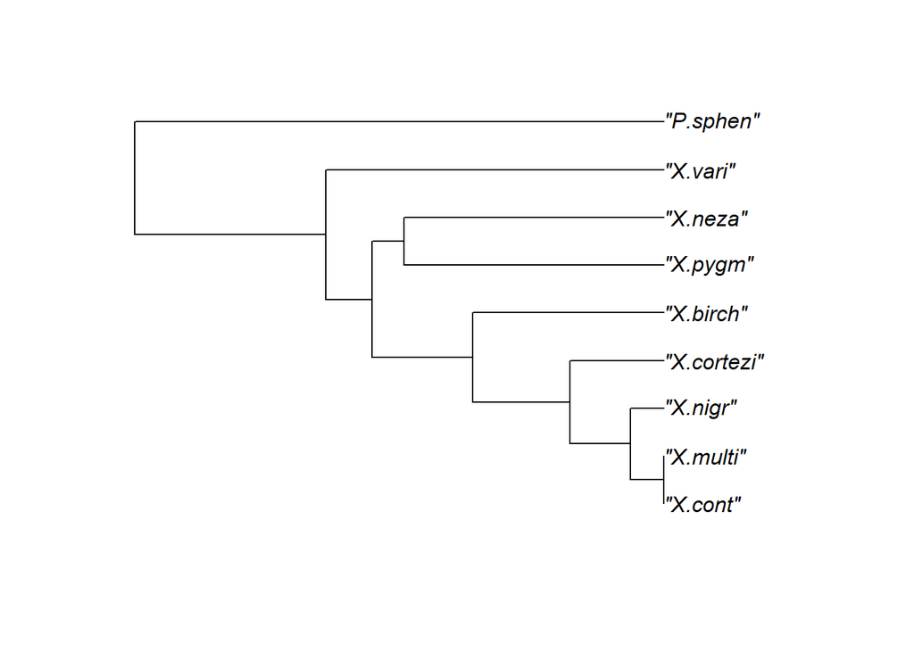

```r
disttree<-dist2tree(distancias) #Agrupamiento gerárcico de las distancias y generación de un árbol a través del método del vecino más cercano.
mytree<-ape::read.tree(text = disttree)
plot.phylo(mytree)
```

En este caso, este árbol nos muestra las relaciones de parentezco entre las especies estudiadas. La longitud de las ramas es proporcional a las distancias genéticas entre cada grupo (donde se forman bifurcaciones). La razón por la que es importante considerar a *P. sphenops* es para conformar lo que se conoce como un taxon externo, el cual nos ayuda a confirmar que las relaciones de parentezco estén bien representadas. Este taxon externo ayuda a enraizar nuestro árbol, y conforma un punto de partida a partir del cual podemos empezar a construir el árbol. Ya que todos los miembros del grupo de estudio deberían quedar agrupados juntos, por separado de nuestro taxon externo.

# 5 Conclusiones